# Mapinguari

## get performace considering microhabitat temperatures

```r
# let's include a new column in the table with CWD
microclimate_by_day$CWD <- raster::extract(mean(CWD_stack), data.frame(Lon = microclimate_by_day$Lon, Lat = microclimate_by_day$Lat))

microtemp_model <-
fit_curves(glm(temp_micro_avg ~ temp_air_avg + CWD, data = microclimate_by_day))
```

```
##            logLik      AIC     BIC dAIC dBIC rankAIC rankBIC
## model_1 -61.40676 130.8135 135.689    0    0       1       1
```

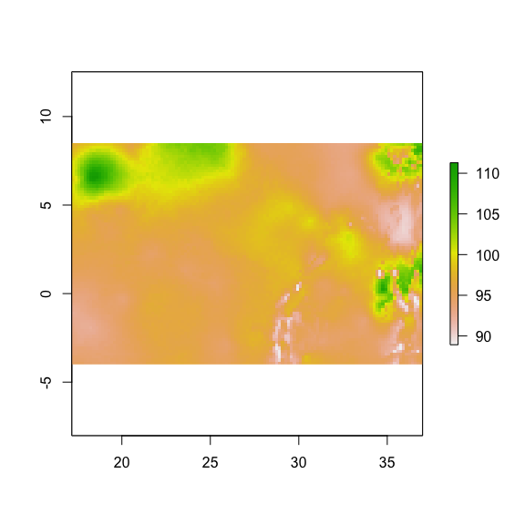

```r
predict_microtemp <- microtemp_model$model_1$predict

#first, let's fix the temperature scale
Fulanus_present_year_averages_scaled <- Fulanus_present_year_averages
Fulanus_present_year_averages_scaled$tmax_average <- Fulanus_present_year_averages$tmax_average/10

Fulanus_present_year_averages_scaled$CWD <- mean(CWD_stack)

microtemp_raster_present <-
  transform_rasters(raster_stack = Fulanus_present_year_averages_scaled,
    FUN_qlist = qlist(microtemp = predict_microtemp(temp_air_avg = tmax, CWD = CWD)))

names(microtemp_raster_present) <- "microtemp"

Perf_rasters_microtemp <-
  transform_rasters(raster_stack = microtemp_raster_present,
                    FUN_qlist = qlist(perf_microtemp = my_tpc(microtemp,
                                                              size = mean(FulanusPhysiology$size))))

plot(mean(Perf_rasters_microtemp))
```

## Creating a function for the Sinervo method for hours of activity

Sometimes, you might want to create a function to use in `transform_rasters` that is not a prediction of a model you can fit with `fit_curves`. `transform_rasters` will take custom functions you make if they are vectorized. There are different ways to vectorize a function, like function `Vectorize`. We are going to make an example function, the Sinervo method for calculating hours of activity (Sinervo 2010), and use it to create a raster of hours of activity. This method creates a sin wave between the minimum and maximum temperatures for a location, simulating daily temperature variation, then counts how much time the temperatures are between the thresholds for activity for that species. This method was developed initially for hours of activity in lizards, but it can be applied for any relevant temperature thresholds, like the limits of the thermal neutral zone in mammals or temperature ranges important for seed or egg development.

```r
# Let's create a function for the Sinervo method
# tmax is the maximum temperature at a location
# tmin is the minimum temperature at a location
# tlwr is the lower temperature threshold for activity
# tupr is the upper temperature threshold for activity
# res is the time resolution, i. e. how many parts of hours are being counted. If res = 3, hours of activity will be counted from 20 to 20 minutes (this will greatly affect the speed of the calculation).

SinervoHA <- function(tmax, tmin, tlwr, tupr, res) {

  s0 <- 1:res
  h0 <- 1:24

  s <- expand.grid(s0, h0)[[1]]
  h <- expand.grid(s0, h0)[[2]]

  day_temps <-
  ((tmax - tmin)/2 * sin((pi/12) * (h + (s/res)) - 3 * (pi/4))) + (tmax + tmin)/2

  sum(ifelse(day_temps > tlwr & day_temps < tupr, 1/res, 0))
}

# We can vectorize the function using function Vectorize

SinervoHA_vectorized <- Vectorize(SinervoHA)

SinervoHA(tmax = c(30, 40, 35), tmin = c(10, 20, 15), tlwr = 20, tupr = 30, res = 3)
```

```
## [1] 10.33333
```

```r
SinervoHA_vectorized(tmax = c(30, 40, 35), tmin = c(20, 30, 25), tlwr = 20, tupr = 30, res = 3)
```

```
## [1] 23.33333  0.00000 11.66667
```

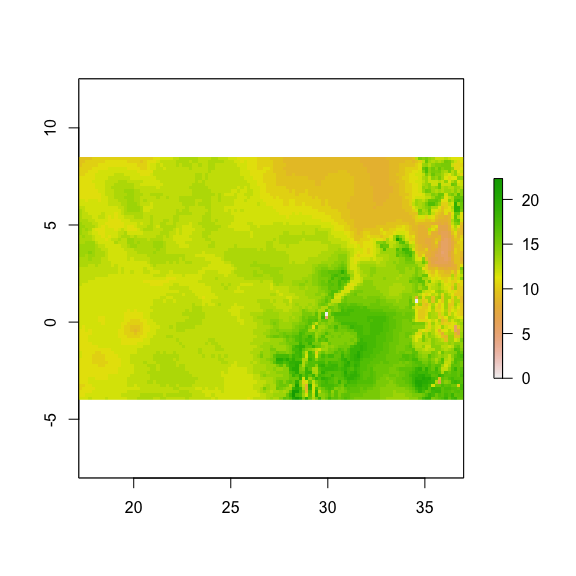

```r
Fulanus_present_year_summaries_scaled <- Fulanus_present_year_summaries

Fulanus_present_year_summaries_scaled$tmax_average_year <- Fulanus_present_year_summaries$tmax_average_year/10

Fulanus_present_year_summaries_scaled$tmin_average_year <- Fulanus_present_year_summaries$tmin_average_year/10

ha_sinervo_raster <-
transform_rasters(raster_stack = Fulanus_present_year_summaries_scaled,
                  FUN_qlist = qlist(SinervoHA_vectorized(tmax = tmax[[1]], tmin = tmin[[1]],  tlwr = 15, tupr = 25, res = 3)))

# Let's cap the hours of activity by daylength

average_daylength <- mean(daylength_stack)

ha_capped <-
overlay(ha_sinervo_raster, average_daylength, fun = function(x, y) ifelse(x < y, x, y))

# hours of restriction to activity
h_restriction <- average_daylength - ha_capped

plot(ha_sinervo_raster)
```

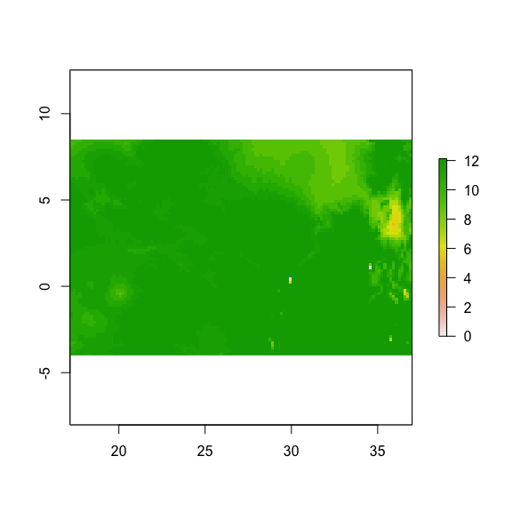

```r
plot(ha_capped)
```

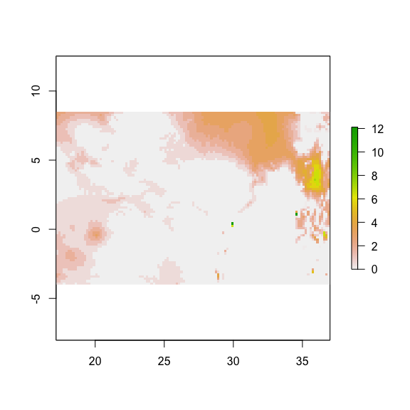

```r
plot(h_restriction)
```

## Cleaning points

Some points might be too close to each other and be redundant, while other might be mistakenly placed in regions where the species is known not to occurr. Fulanus only occurrs between the altitudes of 500 and 1000 meters. Let’s filter out points that are within 2 kilometers from each other and outside the altitude range where the species is know to occurr.

```r
# A reference layer has to be inputed

alt <- FulanusEcoRasters_present$present$alt

FulanusDistribution_clean <-
 clean_points(coord = FulanusDistribution,
   merge_dist = 2,
   reference_layer = alt > 500 & alt < 1000,
   layer_filter = 0)
```

```
##                       [,1]
## n_entries_raw          615
## n_entries_clean         70
## km_resolution_merging    2
```

```r
#library(ggmap)

#ggmap(Fulanus_big) +
#  geom_point(data = FulanusDistribution_clean,
#    mapping = aes(x = Lon, y = Lat),
#    size = 1,
#    colour = 'red')
```

```r
print("That's all")
```

```
## [1] "That's all"
```